# R Notebook

# Loading libraries

```r
library(tidyverse)
library(cluster)
library(factoextra)
library(dendextend)
library(broom)
library(animation)
library(janitor)
library(cluster)
```

# Reading, exploring and plotting data

```r
computers <- read_csv("data/computers.csv")

summary(computers)
```

[output not shown]

```r
computers <- computers %>%
  select(hd, ram)
```

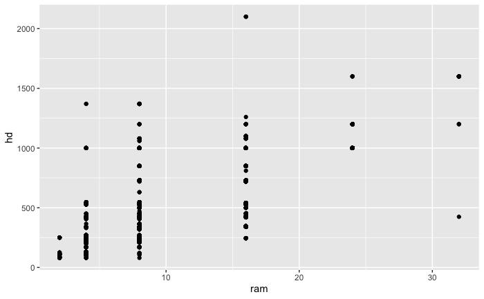

```r
ggplot(computers) +
  aes(x = ram, y = hd) +
  geom_point()
```

After exploring and plotting the data it can be said that the dataset is suitable for clustering analysis as there appears to some well-defined groupings - looks to be 2/3 clear groupings. As the goal is to find patterns between the two variables, k-means is the best clustering analysis option for this.

# Scaling the data

```r
computers_scale <- computers %>%
   mutate_all(scale)
```

# Choosing a k value

3 choosing methods (elbow, silhouette and gap) will be used to determine the k value (most common value will be the chosen k value)

## Elbow

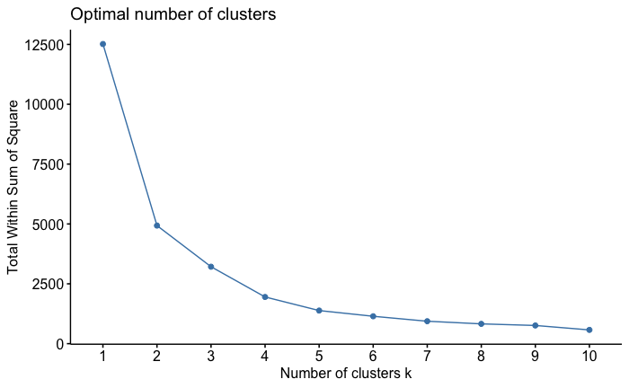

```r
fviz_nbclust(computers_scale, kmeans, method = "wss", nstart = 25)
```

## Silhouette

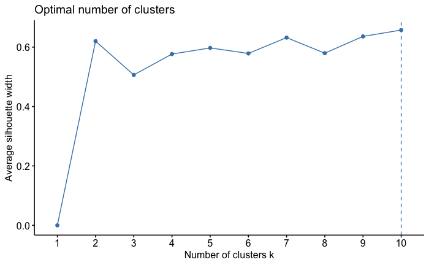

```r
fviz_nbclust(computers_scale, kmeans, method = "silhouette", nstart = 25)
```

#Gap

```r
#fviz_nbclust(computers_scale, kmeans, method = "gap_stat", nstart = 25, k.max = 10)
```

Gap doesn’t seem to be working

The elbow method shows 2 to be the optimal k value while the silhouette method shows 10 to be the optimal (although 2 and 7 looks to meet at the same y value). As the gap method does not appear to work, based on the plots above and the original computers plot, 2 is selected as the k value.

# Visualising the clusters

```r
clustered_computers <- kmeans(computers_scale,
                            centers = 2,
                            nstart = 25)
```

[figure not shown]

[figure not shown]

[figure not shown]

[figure not shown]

[figure not shown]

[figure not shown]

[figure not shown]

[figure not shown]

```r
max_k <- 20

k_clusters <- tibble(k = 1:max_k) %>%
  mutate(
    kclust = map(k, ~ kmeans(computers_scale, .x, nstart = 25)),
    tidied = map(kclust, tidy),
    glanced = map(kclust, glance),
    augmented = map(kclust, augment, computers)
  )


clusterings <- k_clusters %>%
  unnest(glanced)

clusterings
```

| k | kclust | tidied | totss | tot.withinss | betweenss | iter | augmented |
| --- | --- | --- | --- | --- | --- | --- | --- |
| 1 |  |  | 12516 | 12516.0000 | -3.819878e-10 | 1 |  |
| 2 |  |  | 12516 | 4932.6001 | 7.583400e+03 | 1 |  |
| 3 |  |  | 12516 | 3213.7256 | 9.302274e+03 | 2 |  |
| 4 |  |  | 12516 | 1950.5530 | 1.056545e+04 | 3 |  |
| 5 |  |  | 12516 | 1385.9802 | 1.113002e+04 | 2 |  |
| 6 |  |  | 12516 | 1147.7039 | 1.136830e+04 | 2 |  |
| 7 |  |  | 12516 | 933.2597 | 1.158274e+04 | 3 |  |
| 8 |  |  | 12516 | 814.7777 | 1.170122e+04 | 2 |  |
| 9 |  |  | 12516 | 669.0949 | 1.184691e+04 | 2 |  |
| 10 |  |  | 12516 | 507.0038 | 1.200900e+04 | 3 |  |

[output cut: 10 more lines]

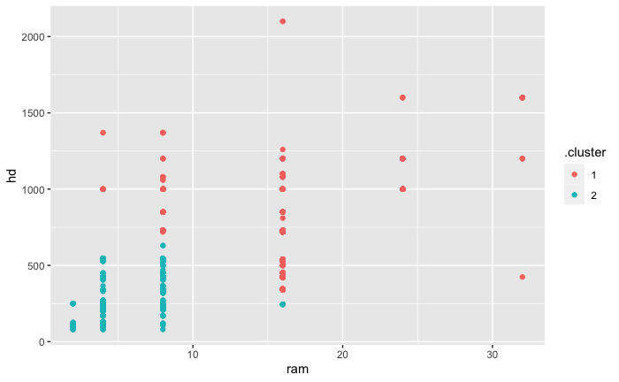

```r
 clusterings %>%
  unnest(cols = c(augmented)) %>%
  filter(k == 2) %>%
  ggplot(aes(x = ram, y = hd, colour = .cluster)) +
  geom_point(aes(color = .cluster))
```

```r
 clusterings %>%
  unnest(augmented) %>%
  filter(k == 2) %>%
  group_by(.cluster) %>%
  summarise(mean(ram), mean(hd))
```

[output not shown]